# Unsupervised Machine Learning Techniques I

## Introduction

We continue our analysis of the healthcare provider dataset containing data on discharges, payments, coverage and medicare payments for 163,065 provider-disease group combinations.

### Data Preparation

We load and prepare the data based on previous week's findings. We perform the following steps:

- Load data
- Convert appropriate variables into float and strong types
- Rename columns to follow convention, and enable easier code blocks
- Create one additional variable for Average out of pocket payments (average_pocket_paments)

```python
#Importing packages required for data analysis and plotting
import pandas as pd
import numpy as np
import plotly
import seaborn as sns
import matplotlib.pyplot as plt
```

```python
#Importing the data using pandas
data = pd.read_csv("icdata.csv")
```

```python
#Understanding the data
#Converting necessary columns into numeric floats
data[' Average Total Payments '] = data[' Average Total Payments '].str.extract(r'(\d+.\d)').astype('float')
data[' Average Covered Charges '] = data[' Average Covered Charges '].str.extract(r'(\d+.\d)').astype('float')
data['Average Medicare Payments'] = data['Average Medicare Payments'].str.extract(r'(\d+.\d)').astype('float')
data['Provider Id'] = data['Provider Id'].astype(str)

data.rename(columns = { "DRG Definition": "DRG_def", "Provider Id": "provider_id", "Provider Name": "provider_name", "Provider Street Address": "provider_street",
                       "Provider City": "provider_city", "Provider State": "provider_state", "Provider Zip Code": "provider_zip",
                       "Hospital Referral Region Description": "hospital_referral_region", " Total Discharges ": "total_discharges",
                       " Average Covered Charges ": "average_covered_charges", " Average Total Payments ": "average_total_payments",
                      "Average Medicare Payments": "average_medicare_payments"}, errors = "raise", inplace = True)

#Calculating out-of-pocket expenses
data['average_pocket_payments'] = data['average_total_payments'] - data['average_medicare_payments']

data.head()
```

|  | DRG_def | provider_id | provider_name | provider_street | provider_city | provider_state | provider_zip | hospital_referral_region | total_discharges | average_covered_charges | average_total_payments | average_medicare_payments | average_pocket_payments |
| --- | --- | --- | --- | --- | --- | --- | --- | --- | --- | --- | --- | --- | --- |
| 0 | 039 - EXTRACRANIAL PROCEDURES W/O CC/MCC | 10001 | SOUTHEAST ALABAMA MEDICAL CENTER | 1108 ROSS CLARK CIRCLE | DOTHAN | AL | 36301 | AL - Dothan | 91 | 32963.0 | 5777.2 | 4763.7 | 1013.5 |
| 1 | 039 - EXTRACRANIAL PROCEDURES W/O CC/MCC | 10005 | MARSHALL MEDICAL CENTER SOUTH | 2505 U S HIGHWAY 431 NORTH | BOAZ | AL | 35957 | AL - Birmingham | 14 | 15131.8 | 5787.5 | 4976.7 | 810.8 |
| 2 | 039 - EXTRACRANIAL PROCEDURES W/O CC/MCC | 10006 | ELIZA COFFEE MEMORIAL HOSPITAL | 205 MARENGO STREET | FLORENCE | AL | 35631 | AL - Birmingham | 24 | 37560.3 | 5434.9 | 4453.7 | 981.2 |
| 3 | 039 - EXTRACRANIAL PROCEDURES W/O CC/MCC | 10011 | ST VINCENT'S EAST | 50 MEDICAL PARK EAST DRIVE | BIRMINGHAM | AL | 35235 | AL - Birmingham | 25 | 13998.2 | 5417.5 | 4129.1 | 1288.4 |
| 4 | 039 - EXTRACRANIAL PROCEDURES W/O CC/MCC | 10016 | SHELBY BAPTIST MEDICAL CENTER | 1000 FIRST STREET NORTH | ALABASTER | AL | 35007 | AL - Birmingham | 18 | 31633.2 | 5658.3 | 4851.4 | 806.9 |

### Basic Ratios

Based on our preliminary resarch and the models identified in current research, we create the following ratios:

- Medicare payments to Total Payments - Typically, Medicare covers about 80% of total payments
- Medicare payments to covered charges - Ideally, average medicare payments should equal or be less than covered charges
- Total payments to covered charges
- Out-of-pocket payments to Medicare Payments

These ratios are widely used within the industry, in addition to identifying abnormallyhigh payments or number of discharges to identify fraud.

```python
#Adding additional data columns to enable factor engineering

data['medicare_by_total'] = (data['average_medicare_payments'] / data['average_total_payments'])
data['medicare_by_covered'] = (data['average_medicare_payments'] / data['average_covered_charges'])
data['total_by_covered'] = (data['average_total_payments'] / data['average_covered_charges'])
data['oop_by_medicare'] = (data['average_pocket_payments'] / data['average_medicare_payments'])
```

## Exploratory Data Analysis

We will revist the exploratory analyses performed to understand the data distribution further.

### Distrbution of Average Medicare Payments

We begin our analysis by looking at the distribution of average medicare payments. We will look at the top 15 providers, states, cities, disease groups and hospital referral groups by count.

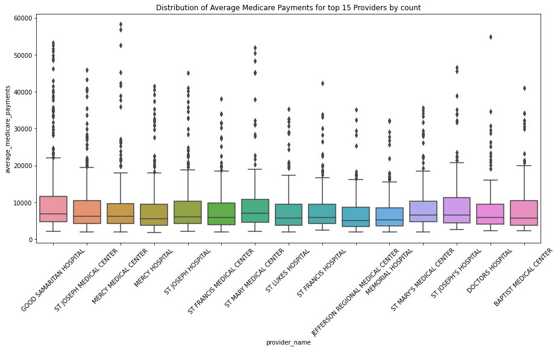

```python
# Distribution of medicare payments across providers
plt.figure(figsize = (15,7))
sns.boxplot(data = data, x = 'provider_name', y = 'average_medicare_payments', order = data['provider_name'].value_counts()[:15].index)
plt.title("Distribution of Average Medicare Payments for top 15 Providers by count")
_ = plt.xticks(rotation = 45)
```

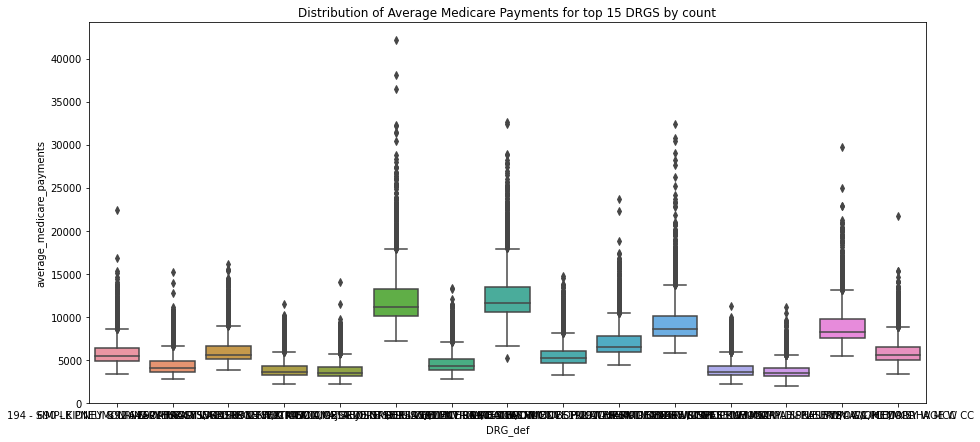

```python
# Distribution of medicare payments across disease groups
plt.figure(figsize = (15,7))
sns.boxplot(data = data, x = 'DRG_def', y = 'average_medicare_payments', order = data['DRG_def'].value_counts()[:15].index)
_ = plt.title("Distribution of Average Medicare Payments for top 15 DRGS by count")
```

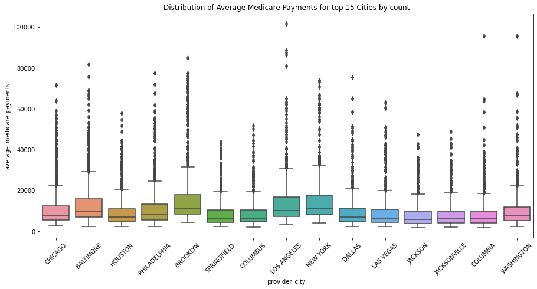

```python
# Distribution of medicare payments across Cities
plt.figure(figsize = (15,7))
sns.boxplot(data = data, x = 'provider_city', y = 'average_medicare_payments', order = data['provider_city'].value_counts()[:15].index)
plt.title("Distribution of Average Medicare Payments for top 15 Cities by count")
_ = plt.xticks(rotation = 45)
```

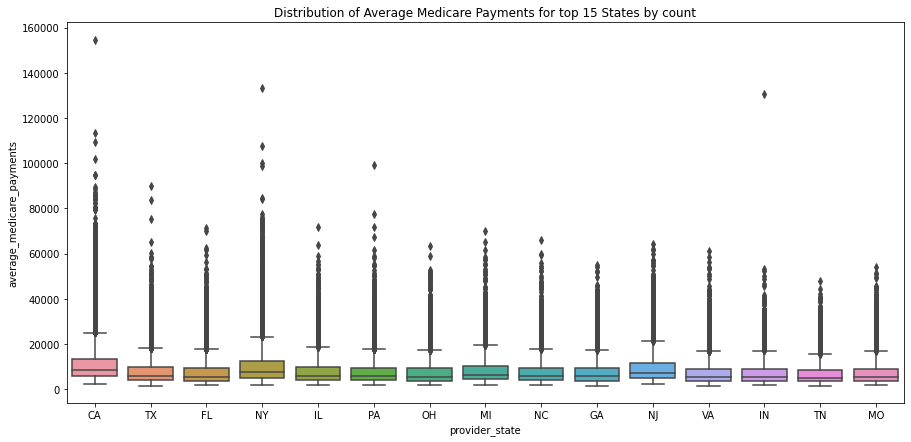

```python
# Distribution of medicare payments across States
plt.figure(figsize =(15,7))
sns.boxplot(data = data, x = 'provider_state', y = 'average_medicare_payments', order = data['provider_state'].value_counts()[:15].index)
_ = plt.title("Distribution of Average Medicare Payments for top 15 States by count")
```

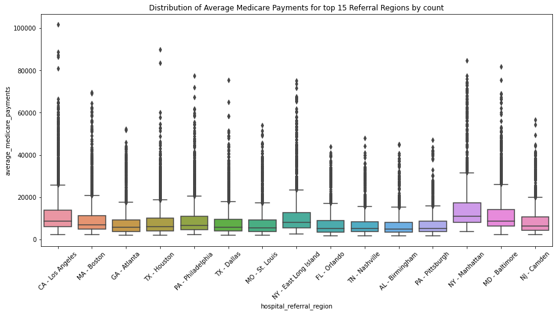

```python
# Distribution of medicare payments across Hospital Referral Groups
plt.figure(figsize = (15,7))
sns.boxplot(data = data, x = 'hospital_referral_region', y = 'average_medicare_payments', order = data['hospital_referral_region'].value_counts()[:15].index)
plt.title("Distribution of Average Medicare Payments for top 15 Referral Regions by count")
_ = plt.xticks(rotation = 45)
```

Across all levels of aggregations, we see that the average medicare payments vary widely. This can be for a number of reasons:

- The specific provider performs more high-cost procedures
- The costs are much higher in the specific state or city, for example, NY.
- The specific DRG requries expensive procedures
- The specific hospital group is within an expensive network.

However, it could also mean that outliers within the respective aggregations are fraudulent and need to be explored further.

### Distribution of Total Discharges

Next , we look at the distribution of total discharges across the top 15 providers, disease groups, cities, states and hospital referral regions

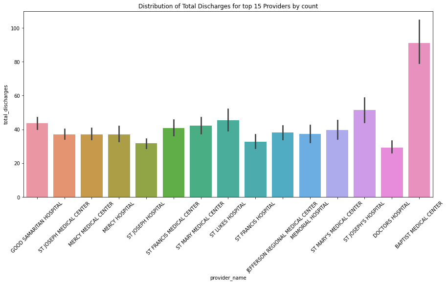

```python
# Distribution of total discharges across providers
plt.figure(figsize= (15,7))
sns.barplot(data = data, x = 'provider_name', y = 'total_discharges', order = data['provider_name'].value_counts()[:15].index)
plt.title("Distribution of Total Discharges for top 15 Providers by count")
_ = plt.xticks(rotation = 45)
```

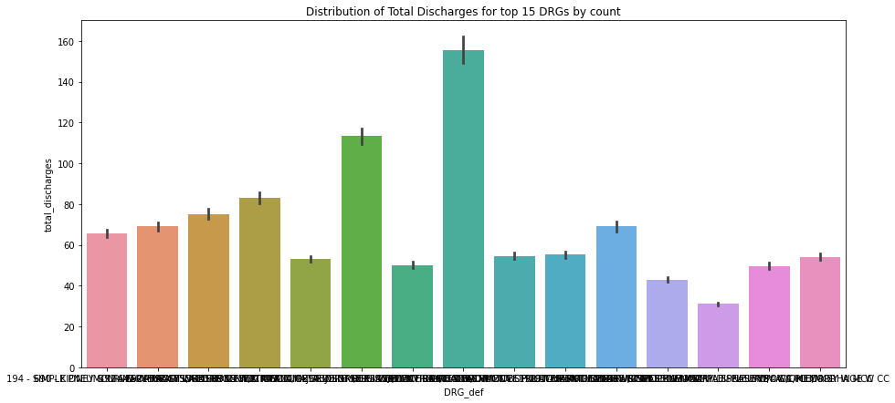

```python
# Distribution of total discharges across DRG
plt.figure(figsize = (15,7))
sns.barplot(data = data, x = 'DRG_def', y = 'total_discharges', order = data['DRG_def'].value_counts()[:15].index)
plt.title("Distribution of Total Discharges for top 15 DRGs by count")
```

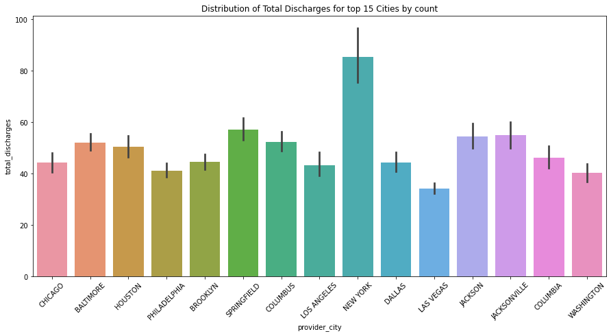

```python
# Distribution of total discharges across Cities
plt.figure(figsize = (15,7))
sns.barplot(data = data, x = 'provider_city', y = 'total_discharges', order = data['provider_city'].value_counts()[:15].index)
plt.title("Distribution of Total Discharges for top 15 Cities by count")
_ = plt.xticks(rotation = 45)
```

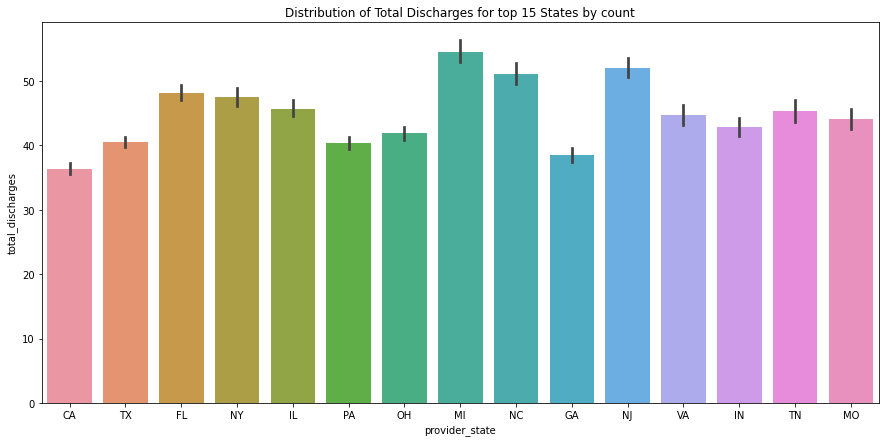

```python
# Distribution of total discharges across States
plt.figure(figsize = (15,7))
sns.barplot(data = data, x = 'provider_state', y = 'total_discharges', order = data['provider_state'].value_counts()[:15].index)
plt.title("Distribution of Total Discharges for top 15 States by count")
```

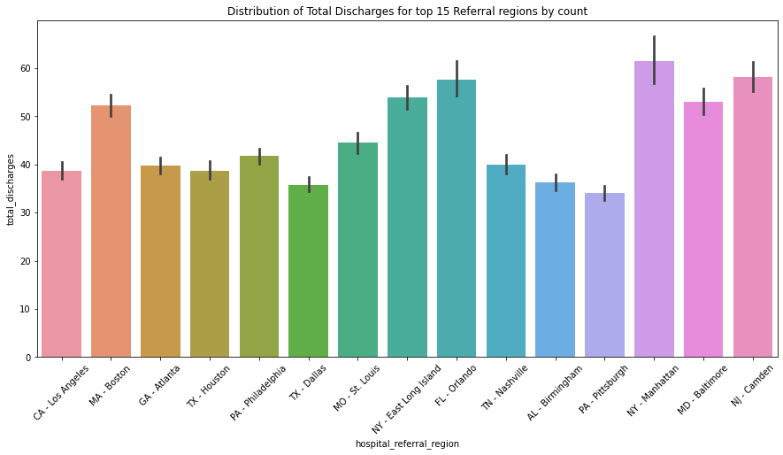

```python
# Distribution of total discharges across hospital referral groups
plt.figure(figsize = (15,7))
sns.barplot(data = data, x = 'hospital_referral_region', y = 'total_discharges', order = data['hospital_referral_region'].value_counts()[:15].index)
plt.title("Distribution of Total Discharges for top 15 Referral regions by count")
_ = plt.xticks(rotation = 45)
```

Across all levels of aggregations, we see that the total discharges vary widely. This can be for a number of reasons:

- The specific provider is widely preferred and is visited by more patients
- The population densities are much higher in the specific state or city, for example, NY.
- The specific DRG is an extremely common ailment
- The specific hospital group is well-know and therefore has many more referrals.

However, it could also mean that outliers within the respective aggregations are fraudulent and need to be explored further.

### Correlation Filtering

Now that we have identified provider, disease group, state, city and referral region as a factor affecting total discharges and average medicare payments. We can begin creating features that use these characterestics. However, first we need to remove variables in the current dataset which are correlated with each other.

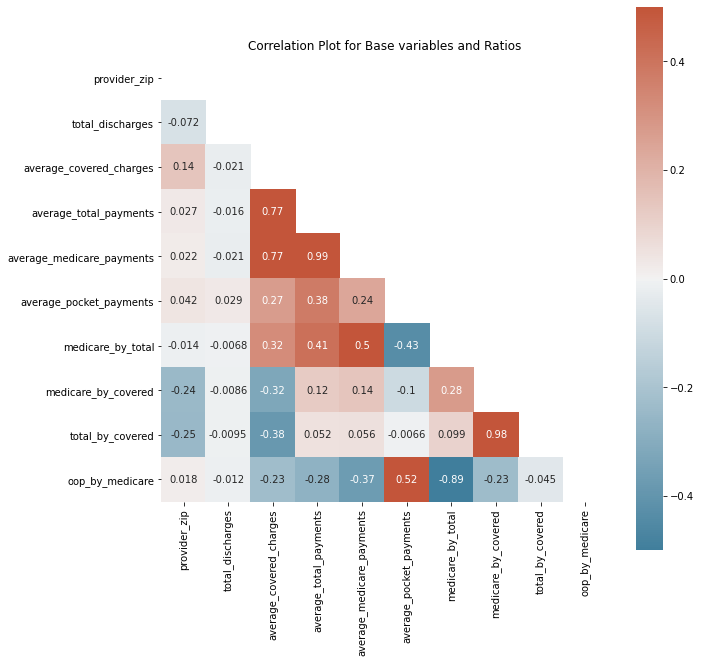

```python
corr = data.corr()
plt.figure(figsize = (10,10))
mask = np.triu(np.ones_like(corr, dtype = bool ))
cmap = sns.diverging_palette(230, 20,  as_cmap = True)
sns.heatmap(corr, mask = mask, cmap = cmap, square = True, annot= True, vmax= 0.5, vmin = -0.5, center= 0.00)
plt.title('Correlation Plot for Base variables and Ratios')
```

Based on the above correlation plot, we will drop the following factors which show a high correlation (Greater than 0.7 or Less than -0.7) to one or more other factors:

- Average Total Payments (High positive correlation to Average medicare payments and Average covered charges)
- Average Covered Charges (High postive correlation to Average medicare payments)
- Ratio of Total Payments to Covered Charges (High positive correlation to ratio of medicare payments to covered charges)
- Ratio of Out of pocket payments to medicare payments (High negative correlation to ratio of medicare payments to total payments)

```python
dropvars1 = ['average_total_payments', 'average_covered_charges', 'total_by_covered', 'oop_by_medicare']
data1 = data.drop(dropvars1, axis = 1)
```

## Feature Engineering

### Calculating Benchmarks

The first step in our feature engineering journey is to create benchmarks for the variables associated with each observation, which we identified earlier:

- Provider (Identified by ID)
- Disease Group (DRG)
- City in which the provider is (Provider_City)
- State in which the provider is (Provider_State)
- Hospital Referral Region which the provider is part of (Hospital_referral_region)

For each of these groups to which the provider belongs we calculated the following benchmarks:

- Median
- Standard Deviation

Benchmarks for were calculated for the following measures:

- Total Discharges
- Average Medicare Payments
- Average Out of Pocket Payments
- Ratio of medicare payments to covered charges
- Ratio of mediare payments to total payments

```python
##### Single level benchmark summaries for provider, city, state, and DRG
data_provider_stat1 = data1[['provider_id', 'total_discharges', 'average_pocket_payments', 'medicare_by_covered', 'average_medicare_payments',
                          'medicare_by_total']].groupby('provider_id').median()
data_provider_stat1.rename(columns = {'provider_id': 'provider_id', 'total_discharges' : 'median_provider_td', 'average_pocket_payments': 'median_provider_oop',
                                      'medicare_by_covered': 'median_provider_mbc', 'average_medicare_payments': 'median_provider_mp',
                                      'medicare_by_total': 'median_provider_mbt'}, inplace = True)

data_state_stat1 = data1[['provider_state', 'total_discharges', 'average_pocket_payments', 'medicare_by_covered', 'average_medicare_payments',
                          'medicare_by_total']].groupby('provider_state').median()
data_state_stat1.rename(columns = {'provider_state': 'provider_state', 'total_discharges' : 'median_state_td', 'average_pocket_payments': 'median_state_oop',
                                      'medicare_by_covered': 'median_state_mbc', 'average_medicare_payments': 'median_state_mp',
                                      'medicare_by_total': 'median_state_mbt'}, inplace = True)

data_city_stat1 = data1[['provider_city', 'total_discharges', 'average_pocket_payments', 'medicare_by_covered', 'average_medicare_payments',
                          'medicare_by_total']].groupby('provider_city').median()
data_city_stat1.rename(columns = {'provider_city': 'provider_city', 'total_discharges' : 'median_city_td', 'average_pocket_payments': 'median_city_oop',
                                      'medicare_by_covered': 'median_city_mbc', 'average_medicare_payments': 'median_city_mp',
                                      'medicare_by_total': 'median_city_mbt'}, inplace = True)

data_drg_stat1 = data1[['DRG_def', 'total_discharges', 'average_pocket_payments', 'medicare_by_covered', 'average_medicare_payments',
                          'medicare_by_total']].groupby('DRG_def').median()
data_drg_stat1.rename(columns = {'DRG_def': 'DRG_def', 'total_discharges' : 'median_drg_td', 'average_pocket_payments': 'median_drg_oop',
                                      'medicare_by_covered': 'median_drg_mbc', 'average_medicare_payments': 'median_drg_mp',
                                      'medicare_by_total': 'median_drg_mbt'}, inplace = True)


data_provider_stat2 = data1[['provider_id', 'total_discharges', 'average_pocket_payments', 'medicare_by_covered', 'average_medicare_payments',
                          'medicare_by_total']].groupby('provider_id').std()
data_provider_stat2.rename(columns = {'provider_id': 'provider_id', 'total_discharges' : 'sd_provider_td', 'average_pocket_payments': 'sd_provider_oop',
                                      'medicare_by_covered': 'sd_provider_mbc', 'average_medicare_payments': 'sd_provider_mp',
                                      'medicare_by_total': 'sd_provider_mbt'}, inplace = True)

data_state_stat2 = data1[['provider_state', 'total_discharges', 'average_pocket_payments', 'medicare_by_covered', 'average_medicare_payments',
                          'medicare_by_total']].groupby('provider_state').std()
data_state_stat2.rename(columns = {'provider_state': 'provider_state', 'total_discharges' : 'sd_state_td', 'average_pocket_payments': 'sd_state_oop',
                                      'medicare_by_covered': 'sd_state_mbc', 'average_medicare_payments': 'sd_state_mp',
                                      'medicare_by_total': 'sd_state_mbt'}, inplace = True)

data_city_stat2 = data1[['provider_city', 'total_discharges', 'average_pocket_payments', 'medicare_by_covered', 'average_medicare_payments',
                          'medicare_by_total']].groupby('provider_city').std()
data_city_stat2.rename(columns = {'provider_city': 'provider_city', 'total_discharges' : 'sd_city_td', 'average_pocket_payments': 'sd_city_oop',
                                      'medicare_by_covered': 'sd_city_mbc', 'average_medicare_payments': 'sd_city_mp',
                                      'medicare_by_total': 'sd_city_mbt'}, inplace = True)

data_drg_stat2 = data1[['DRG_def', 'total_discharges', 'average_pocket_payments', 'medicare_by_covered', 'average_medicare_payments',
                          'medicare_by_total']].groupby('DRG_def').std()
data_drg_stat2.rename(columns = {'DRG_def': 'DRG_def', 'total_discharges' : 'sd_drg_td', 'average_pocket_payments': 'sd_drg_oop',
                                      'medicare_by_covered': 'sd_drg_mbc', 'average_medicare_payments': 'sd_drg_mp',
                                      'medicare_by_total': 'sd_drg_mbt'}, inplace = True)

data_provider_stat1.head()
```

| provider_id | median_provider_td | median_provider_oop | median_provider_mbc | median_provider_mp | median_provider_mbt |
| --- | --- | --- | --- | --- | --- |
| 100001 | 37.5 | 812.65 | 0.287529 | 8862.10 | 0.918824 |
| 100002 | 34.5 | 922.05 | 0.161144 | 6586.00 | 0.878591 |
| 100006 | 73.0 | 1210.10 | 0.163853 | 6218.30 | 0.838262 |
| 100007 | 189.5 | 1425.95 | 0.166507 | 5743.55 | 0.801027 |
| 100008 | 46.0 | 1121.10 | 0.141974 | 7633.50 | 0.851791 |

As can be seen above, we followed a simple naming convention for the benchmarks created.

The first word would signify the measure (mean or standard deviation), followed one to two words signifying the aggregation level (For example, provider or DRGxState) and the last word would signify the variable (For exampple, td means total discharges). Simply,

- sd_drg_mbc : Standard deviation for Medicare payments by Covered Charges for each DRG

And so on.

```python
###### DUAL Level summary benchmarks for DRG and State

data_drg_state_stat1 = data1[['DRG_def', 'provider_state', 'total_discharges', 'average_medicare_payments', 'average_pocket_payments', 'medicare_by_covered', 'medicare_by_total'
                          ]].groupby(['DRG_def', 'provider_state']).median()
data_drg_state_stat1.rename(columns = {'DRG_def': 'DRG_def', 'provider_state': 'provider_state', 'total_discharges' : 'median_drg_state_td', 'average_pocket_payments': 'median_drg_state_oop',
                                      'medicare_by_covered': 'median_drg_state_mbc', 'average_medicare_payments': 'median_drg_state_mp',
                                      'medicare_by_total': 'median_drg_state_mbt'}, inplace = True)

data_drg_state_stat2 = data1[['DRG_def', 'provider_state', 'total_discharges', 'average_medicare_payments', 'average_pocket_payments', 'medicare_by_covered', 'medicare_by_total'
                          ]].groupby(['DRG_def', 'provider_state']).std()
data_drg_state_stat2.rename(columns = {'DRG_def': 'DRG_def', 'provider_state': 'provider_state', 'total_discharges' : 'sd_drg_state_td', 'average_pocket_payments': 'sd_drg_state_oop',
                                      'medicare_by_covered': 'sd_drg_state_mbc', 'average_medicare_payments': 'sd_drg_state_mp',
                                      'medicare_by_total': 'sd_drg_state_mbt'}, inplace = True)

###### DUAL Level summary benchmarks for DRG and Referral Region

data_drg_rfg_stat1 = data1[['DRG_def', 'hospital_referral_region','total_discharges', 'average_medicare_payments', 'average_pocket_payments', 'medicare_by_covered', 'medicare_by_total'
                           ]].groupby(['DRG_def', 'hospital_referral_region']).median()
data_drg_rfg_stat1.rename(columns = {'DRG_def': 'DRG_def', 'hospital_referral_region': 'hospital_referral_region', 'total_discharges' : 'median_drg_rfg_td', 'average_pocket_payments': 'median_drg_rfg_oop',
                                      'medicare_by_covered': 'median_drg_rfg_mbc', 'average_medicare_payments': 'median_drg_rfg_mp',
                                      'medicare_by_total': 'median_drg_rfg_mbt'}, inplace = True)

data_drg_rfg_stat2 = data1[['DRG_def', 'hospital_referral_region','total_discharges', 'average_medicare_payments', 'average_pocket_payments', 'medicare_by_covered', 'medicare_by_total'
                           ]].groupby(['DRG_def', 'hospital_referral_region']).std()
data_drg_rfg_stat2.rename(columns = {'DRG_def': 'DRG_def', 'hospital_referral_region': 'hospital_referral_region', 'total_discharges' : 'sd_drg_rfg_td', 'average_pocket_payments': 'sd_drg_rfg_oop',
                                      'medicare_by_covered': 'sd_drg_rfg_mbc', 'average_medicare_payments': 'sd_drg_rfg_mp',
                                      'medicare_by_total': 'sd_drg_rfg_mbt'}, inplace = True)

data_drg_rfg_stat2.head()
```

| DRG_def | hospital_referral_region | sd_drg_rfg_td | sd_drg_rfg_mp | sd_drg_rfg_oop | sd_drg_rfg_mbc | sd_drg_rfg_mbt |
| --- | --- | --- | --- | --- | --- | --- |
| 039 - EXTRACRANIAL PROCEDURES W/O CC/MCC | AK - Anchorage | NaN | NaN | NaN | NaN | NaN |
|  | AL - Birmingham | 11.087646 | 492.763393 | 344.244026 | 0.110399 | 0.036626 |
|  | AL - Dothan | 32.526912 | 251.376461 | 46.315494 | 0.023489 | 0.001103 |
|  | AL - Huntsville | 76.367532 | 508.621908 | 199.757666 | 0.215657 | 0.043066 |
|  | AL - Mobile | 20.676073 | 372.485298 | 435.693686 | 0.100643 | 0.067520 |

In this manner, we have summary statistics across the following aggregations:

- Single level
  - Provider
  - State
  - City
  - Disease group
- Dual level
  - Disease group and State
  - Disease group and referral group

### Calculating Deviation Measures

We left-join the benchmark statistics to our dataframe to enable calculation of deviation measures

```python
####### Combining with the main data frame

### Base level combination
data1 = data1.merge(data_provider_stat1, on = 'provider_id', how = 'left')
data1 = data1.merge(data_provider_stat2, on = 'provider_id', how = 'left')

data1 = data1.merge(data_state_stat1, on = 'provider_state', how = 'left')
data1 = data1.merge(data_state_stat2, on = 'provider_state', how = 'left')

data1 = data1.merge(data_city_stat1, on = 'provider_city', how = 'left')
data1 = data1.merge(data_city_stat2, on = 'provider_city', how = 'left')

data1 = data1.merge(data_drg_stat1, on = 'DRG_def', how = 'left')
data1 = data1.merge(data_drg_stat2, on = 'DRG_def', how = 'left')

#level 1 - drg X state
data1 = pd.merge(data1, data_drg_state_stat1, left_on = ['DRG_def', 'provider_state'], right_on = ['DRG_def', 'provider_state'])
data1 = pd.merge(data1, data_drg_state_stat2, left_on = ['DRG_def', 'provider_state'], right_on = ['DRG_def', 'provider_state'])

#level 1 - drg X referral group
data1 = pd.merge(data1, data_drg_rfg_stat1, left_on = ['DRG_def', 'hospital_referral_region'], right_on = ['DRG_def', 'hospital_referral_region'])
data1 = pd.merge(data1, data_drg_rfg_stat2, left_on = ['DRG_def', 'hospital_referral_region'], right_on = ['DRG_def', 'hospital_referral_region'])
```

Using the benchmark statistics we have calculated so far, for each observation we created a measure of deviation defined as the number of standard deviations above/below the mean.

This deviation, similar to a Z-score, can be calculated at the level of each aggregation identified previously. The naming convention followed is straightforward:

All deviation measures start with dev_ followed by the aggregation level (provider or state or DRG and so on) and end with the variable name (td or mp or mbc and so on). For example,

- dev_provider_td : Deviation of total discharge from the benchmark for this provider
- dev_DRG_mbc : Deviation of the ratio of medicare payments to covered charges for this specific DRG

```python
#Creating deviation measures ( abs(value - mean)/std deviation)
#deviation measure for provider mean and drg and state median
data1['dev_provider_oop'] = (data1['average_pocket_payments'] - data1['median_provider_oop'])/data1['sd_provider_oop']
data1['dev_provider_mbc'] = (data1['medicare_by_covered'] - data1['median_provider_mbc'])/data1['sd_provider_mbc']
data1['dev_provider_mp'] = (data1['average_medicare_payments'] - data1['median_provider_mp'])/data1['sd_provider_mp']
data1['dev_provider_td'] = (data1['total_discharges'] - data1['median_provider_td'])/data1['sd_provider_td']
data1['dev_provider_mbt']= (data1['medicare_by_total'] - data1['median_provider_mbt']) / data1['sd_provider_mbt']

data1['dev_state_oop'] = (data1['average_pocket_payments'] - data1['median_state_oop'])/data1['sd_state_oop']
data1['dev_state_mbc'] = (data1['medicare_by_covered'] - data1['median_state_mbc'])/data1['sd_state_mbc']
data1['dev_state_mp'] = (data1['average_medicare_payments'] - data1['median_state_mp'])/data1['sd_state_mp']
data1['dev_state_td'] = (data1['total_discharges'] - data1['median_state_td'])/data1['sd_state_td']
data1['dev_state_mbt']= (data1['medicare_by_total'] - data1['median_state_mbt']) / data1['sd_state_mbt']

data1['dev_city_oop'] = (data1['average_pocket_payments'] - data1['median_city_oop'])/data1['sd_city_oop']
data1['dev_city_mbc'] = (data1['medicare_by_covered'] - data1['median_city_mbc'])/data1['sd_city_mbc']
data1['dev_city_mp'] = (data1['average_medicare_payments'] - data1['median_city_mp'])/data1['sd_city_mp']
data1['dev_city_td'] = (data1['total_discharges'] - data1['median_city_td'])/data1['sd_city_td']
data1['dev_city_mbt']= (data1['medicare_by_total'] - data1['median_city_mbt']) / data1['sd_city_mbt']

data1['dev_drg_oop'] = (data1['average_pocket_payments'] - data1['median_drg_oop'])/data1['sd_drg_oop']
data1['dev_drg_mbc'] = (data1['medicare_by_covered'] - data1['median_drg_mbc'])/data1['sd_drg_mbc']
data1['dev_drg_mp'] = (data1['average_medicare_payments'] - data1['median_drg_mp'])/data1['sd_drg_mp']
data1['dev_drg_td'] = (data1['total_discharges'] - data1['median_drg_td'])/data1['sd_drg_td']
data1['dev_drg_mbt']= (data1['medicare_by_total'] - data1['median_drg_mbt']) / data1['sd_drg_mbt']

#deviation measure for drg and state
data1['dev_drg_state_oop'] = (data1['average_pocket_payments'] - data1['median_drg_state_oop'])/data1['sd_drg_state_oop']
data1['dev_drg_state_mbc'] = (data1['medicare_by_covered'] - data1['median_drg_state_mbc'])/data1['sd_drg_state_mbc']
data1['dev_drg_state_mp'] = (data1['average_medicare_payments'] - data1['median_drg_state_mp'])/data1['sd_drg_state_mp']
data1['dev_drg_state_td'] = (data1['total_discharges'] - data1['median_drg_state_td'])/data1['sd_drg_state_td']
data1['dev_drg_state_mbt']= (data1['medicare_by_total'] - data1['median_drg_state_mbt']) / data1['sd_drg_state_mbt']

#deviation measure for drg and hospital referral group
data1['dev_drg_rfg_oop'] = (data1['average_pocket_payments'] - data1['median_drg_rfg_oop'])/data1['sd_drg_rfg_oop']
data1['dev_drg_rfg_mbc'] = (data1['medicare_by_covered'] - data1['median_drg_rfg_mbc'])/data1['sd_drg_rfg_mbc']
data1['dev_drg_rfg_mp'] = (data1['average_medicare_payments'] - data1['median_drg_rfg_mp'])/data1['sd_drg_rfg_mp']
data1['dev_drg_rfg_td'] = (data1['total_discharges'] - data1['median_drg_rfg_td'])/data1['sd_drg_rfg_td']
data1['dev_drg_rfg_mbt']= (data1['medicare_by_total'] - data1['median_drg_rfg_mbt']) / data1['sd_drg_rfg_mbt']
```

With these new features we have a measure of the number of standard deviations from the mean for:

- average medicare payments
- Total Discharges
- average out of pocket payment
- Ratio of medicare payment to covered charges
- Ration of medicare payment to total payment

For each of these, we have deviations from mean at the level of :

- Provider
- Disease Group
- State
- City
- Disease group by each state
- Disease group by each hospital referral region

### Filtering for Correlation

Next, we clean up the engineered features and prepare for modelling. We perform the following steps:

- Remove all benchmark variables from the dataset
- Replace all missing values, NaNs and InF with mean values
- Use one hot encoding to convert categorical variables into numerical variables
- Check for correlation
- Remove highly correlated variables

```python
#Cleanin up data for modelling by removing factors and null values
drop_vars = data1.iloc[:, 13:73].columns.tolist()
#Creating index of columns with null values
null_col = data1.isnull().sum().sort_values(ascending = False)
null_col = null_col[ null_col > 0]
#Looping through to replace NAs with mean values
null_col = null_col.index
for col in null_col:
  data1.loc[:, col].fillna(data1.loc[:, col].mean(), inplace = True)
```

```python
#Recategorizing variables to enable one hot encoding
drg_levels = data1['DRG_def'].value_counts().nlargest(25).index.tolist()
data1['new_drg'] = data1['DRG_def'].apply(lambda x: x if x in drg_levels else 'other')
hrr_levels = data1['hospital_referral_region'].value_counts(normalize = True).nlargest(25).index.tolist()
data1['new_hrr'] = data1['hospital_referral_region'].apply(lambda x: x if x in hrr_levels else 'other')
state_levels = data1['provider_state'].value_counts(normalize = True).nlargest(25).index.tolist()
data1['new_state'] = data1['provider_state'].apply(lambda x: x if x in state_levels else 'other')
pid_levels = data1['provider_id'].value_counts(normalize = True).nlargest(25).index.tolist()
data1['new_pid'] = data1['provider_id'].apply(lambda x: x if x in pid_levels else 'other')
```

```python
dummy_drg = pd.get_dummies(data1['new_drg'], dummy_na=False, drop_first= True)
dummy_state = pd.get_dummies(data1['new_state'], dummy_na=False, drop_first= True)
dummy_hrr = pd.get_dummies(data1['new_hrr'], dummy_na=False, drop_first= True)
dummy_pid = pd.get_dummies(data1['new_pid'], dummy_na=False, drop_first= True)
```

```python
#preparing the data
#Copying data into new df
data_model = data1.copy()
data_model = pd.concat([data_model, dummy_drg], axis = 1)
data_model = pd.concat([data_model, dummy_state], axis = 1)
data_model = pd.concat([data_model, dummy_hrr], axis = 1)
data_model = pd.concat([data_model, dummy_pid], axis = 1)
#Removing factor data
drop_cols = ['DRG_def', 'provider_id', 'provider_name', 'provider_street', 'provider_city', 'provider_state', 'provider_zip', 'hospital_referral_region', 'new_hrr', 'new_drg', 'new_state', 'new_pid']
data_model = data_model.drop(drop_cols, axis = 1)
data_model = data_model.drop(drop_vars, axis = 1)
#data_model.info()
```

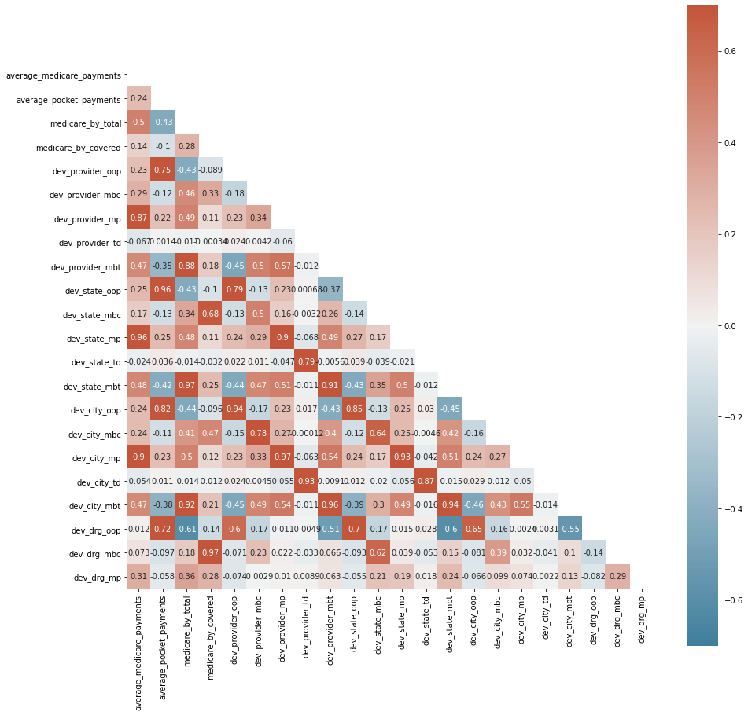

```python
#Checking for correlation
newdata = data_model.iloc[:, 1:23]
ncorr = newdata.corr()
plt.figure(figsize = (15, 15))
mask = np.triu(np.ones_like(ncorr, dtype = bool ))
cmap = sns.diverging_palette(230, 20,  as_cmap = True)
_ = sns.heatmap(ncorr, mask = mask, cmap = cmap, square = True, annot= True, vmax= 0.7, vmin = -0.7, center= 0.00)
```

```python
#dropping highly correlated variables
dropvars2 = ['dev_city_mp', 'dev_city_mbt', 'dev_drg_oop', 'dev_drg_mbc', 'dev_drg_mbt', 'dev_drg_state_mp', 'dev_drg_state_td', 'dev_drg_state_oop', 'dev_drg_rfg_mbc', 'dev_drg_rfg_oop', 'dev_drg_rfg_td', 'dev_drg_rfg_mbt']
data_model = data_model.drop(dropvars2, axis = 1)
```

This leaves us with the following factors for clustering:

- 7 Base features: DRG, State, Provider, Hospital Referral Group, Total discharges, Average medicare payments, Averge out of pocket payments
- 2 Ratios: Medicare payments to covered charges, medicare payments to total payments
- 18 deviation measures

We already visually examined distribution for some of the Base features. In the next section, we will examine ratios and deviation measures.

### Visual Examination

We already examined distributions for average medicare payments and total discharges. Let us examine, one ratio and one deviation measure here

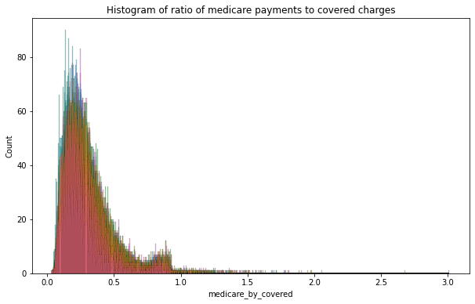

```python
#Exploratory analysis of new variables
plt.figure(figsize = (10,6))
sns.histplot(x = 'medicare_by_covered', hue = 'DRG_def', data = data1, legend = False)
plt.title("Histogram of ratio of medicare payments to covered charges")
```

```python
data1[data1['medicare_by_covered'] > 1.5].head()
```

|  | DRG_def | provider_id | provider_name | provider_street | provider_city | provider_state | provider_zip | hospital_referral_region | total_discharges | average_medicare_payments | ... | dev_drg_state_mbt | dev_drg_rfg_oop | dev_drg_rfg_mbc | dev_drg_rfg_mp | dev_drg_rfg_td | dev_drg_rfg_mbt | new_drg | new_hrr | new_state | new_pid |
| --- | --- | --- | --- | --- | --- | --- | --- | --- | --- | --- | --- | --- | --- | --- | --- | --- | --- | --- | --- | --- | --- |
| 18728 | 191 - CHRONIC OBSTRUCTIVE PULMONARY DISEASE W CC | 330080 | LINCOLN MEDICAL & MENTAL HEALTH CENTER | 234 EAST 149TH STREET | BRONX | NY | 10451 | NY - Bronx | 40 | 13015.4 | ... | 1.105620 | 0.013445 | 1.848151 | 0.040810 | 0.013563 | 0.013785 | 191 - CHRONIC OBSTRUCTIVE PULMONARY DISEASE W CC | other | NY | other |
| 19184 | 178 - RESPIRATORY INFECTIONS & INFLAMMATIONS W CC | 330008 | WYOMING COUNTY COMMUNITY HOSPITAL | 400 NORTH MAIN STREET | WARSAW | NY | 14569 | NY - Rochester | 18 | 10398.2 | ... | 0.714538 | -0.940455 | 2.924408 | 1.798791 | 0.227485 | 1.745351 | other | other | NY | other |
| 25054 | 190 - CHRONIC OBSTRUCTIVE PULMONARY DISEASE W MCC | 510086 | WELCH COMMUNITY HOSPITAL | 454 MCDOWELL STREET | WELCH | WV | 24801 | VA - Roanoke | 11 | 12661.3 | ... | 1.866063 | -0.079652 | 3.395463 | 3.322634 | -1.105278 | 0.865443 | 190 - CHRONIC OBSTRUCTIVE PULMONARY DISEASE W MCC | other | other | other |
| 28375 | 192 - CHRONIC OBSTRUCTIVE PULMONARY DISEASE W/... | 320067 | GUADALUPE COUNTY HOSPITAL | 117 CAMINO DE VIDA | SANTA ROSA | NM | 88435 | NM - Albuquerque | 11 | 11241.6 | ... | 2.427082 | -0.032372 | 3.928596 | 3.472132 | -0.511244 | 1.756670 | 192 - CHRONIC OBSTRUCTIVE PULMONARY DISEASE W/... | other | other | other |
| 34739 | 195 - SIMPLE PNEUMONIA & PLEURISY W/O CC/MCC | 320067 | GUADALUPE COUNTY HOSPITAL | 117 CAMINO DE VIDA | SANTA ROSA | NM | 88435 | NM - Albuquerque | 14 | 11174.7 | ... | 1.837404 | -2.227758 | 3.817209 | 3.698402 | -0.596569 | 2.558658 | 195 - SIMPLE PNEUMONIA & PLEURISY W/O CC/MCC | other | other | other |

5 rows × 107 columns

The ratio of medicare payments to covered charges for a majority of observations fall between 0 and 1. However, a non-zero number of observations have a ratio of average medicare payment to covered charges above 1, and some above 2 as well. Prima facie, this seems suspicious and is worth exploring further. When we look at the observations, we see that almost all observations have ~90% medicare to total payment ratio. This ratio can therefore serve as an important feature in clustering the observations.

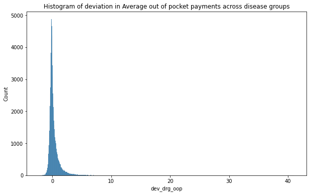

```python
#Exploratory analysis of new variables
plt.figure(figsize = (10,6))
sns.histplot(x = 'dev_drg_oop', data = data1, legend = False)
plt.title("Histogram of deviation in Average out of pocket payments across disease groups")
```

As can be seen, most of the observations in our dataset have very little deviation in out of pocket payments for each DRG. However, A significant number of observations have deviation more than 2 standard deviations above! It is definitely worth examining.

Now our data is clean and ready to be clustered.

## Unsupervised Clustering

Before we use pyOD to identify outliers, we will attempt to cluster these observations on the basis of the available data. This serves two purposes:

1. Reducing the number of observations which need to be examined manually
2. Provide a model for identifying fraudulent transaction as they happen

### Setting Up for K-Means Clustering

For K-means clustering, we perform the following steps:

- Scale and standardize the numerical data using scikit learn
- Use multiple K-values to identify the best number of clusters
- Draw an elbow plot to identify the elbow and best cluster number

```python
#Loading required packages
from sklearn.cluster import KMeans
from sklearn.preprocessing import StandardScaler
```

```python
#Standardizing all values
scaler = StandardScaler()
data_model = scaler.fit_transform(data_model)
```

```python
#Preparing the model
#Identifying best set of clusters
sse = []

for n in range(2,20):
  kmeans = KMeans(n_clusters = n, random_state= 257)
  kmeans.fit(data_model)
  sse.append(kmeans.inertia_)
```

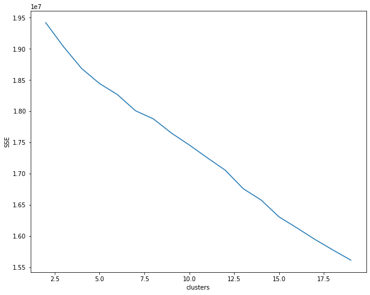

```python
model_sse = pd.DataFrame(data = { 'clusters' : range(2,20), 'SSE' : sse})

plt.figure(figsize= (10,8))
sns.lineplot(x = 'clusters', y = 'SSE', data = model_sse)
```

In order to identify the ideal number of clusters, we tested clusters from 2 to 20. We then drew an elbow plot to identify the best option. Based on the lowest SSE plot, 8 clusters seems to be the best option.

### K-Means Clustering Model with 8 Clusters

Based on our setup, we model with 8 clusters and examine our clusters.

```python
#Building a 8 cluster model
kmm = KMeans(n_clusters = 8, random_state= 250)
kmm.fit(data_model)
```

```
KMeans(random_state=250)
```

```python
#adding the labels to the dataset
data_check = data.copy()
#data_check = data_check.drop(drop_vars, axis = 1)
data_check['label'] = kmm.labels_
```

```python
print("Percentage of observation in each cluster")
data_check['label'].value_counts(normalize = True) * 100
```

```
Percentage of observation in each cluster
```

[output not shown]

```python
print('Number of unique DRGs in each cluster')
data_check[['label', 'DRG_def']].groupby('label').nunique()
```

```
Number of unique DRGs in each cluster
```

| label | DRG_def |
| --- | --- |
| 0 | 100 |
| 1 | 100 |
| 2 | 99 |
| 3 | 99 |
| 4 | 98 |
| 5 | 93 |
| 6 | 90 |
| 7 | 93 |

```python
#adding the labels to the dataset
data_check2 = data1.copy()
data_check2 = data_check2.drop(drop_vars, axis = 1)
data_check2['label'] = kmm.labels_

#summarizing values by label
data_check2[['total_discharges', 'average_medicare_payments', 'medicare_by_total', 'medicare_by_covered', 'dev_drg_mp', 'dev_drg_mbc', 'label', 'dev_drg_td', 'dev_drg_mbt', 'dev_city_td']].groupby('label').median().sort_values(by = 'average_medicare_payments', ascending = False)
```

| label | total_discharges | average_medicare_payments | medicare_by_total | medicare_by_covered | dev_drg_mp | dev_drg_mbc | dev_drg_td | dev_drg_mbt | dev_city_td |
| --- | --- | --- | --- | --- | --- | --- | --- | --- | --- |
| 0 | 22.0 | 12485.65 | 0.757195 | 0.214637 | -0.201588 | -0.246698 | -0.123165 | -2.112352 | -0.136306 |
| 1 | 23.0 | 9337.20 | 0.918685 | 0.297475 | 0.170844 | 0.218767 | -0.133654 | 0.219321 | -0.092069 |
| 3 | 34.0 | 8176.00 | 0.896047 | 0.844401 | 1.403504 | 3.729178 | 0.412936 | 0.503303 | 0.000000 |
| 5 | 34.0 | 6984.60 | 0.886985 | 0.486401 | 0.541230 | 1.555223 | 0.322618 | 0.336786 | 0.034101 |
| 6 | 38.5 | 6949.75 | 0.805009 | 0.164429 | 0.493756 | -0.570775 | 0.917433 | -0.761492 | 0.000000 |
| 4 | 116.0 | 6305.90 | 0.857668 | 0.246000 | 0.034914 | -0.100213 | 1.167467 | -0.087668 | 2.063862 |
| 7 | 29.0 | 4745.05 | 0.838845 | 0.241964 | -0.131110 | -0.043438 | -0.057559 | -0.111034 | 0.109280 |
| 2 | 26.0 | 4118.30 | 0.799886 | 0.206219 | -0.154976 | -0.177327 | -0.052034 | -0.280362 | 0.000000 |

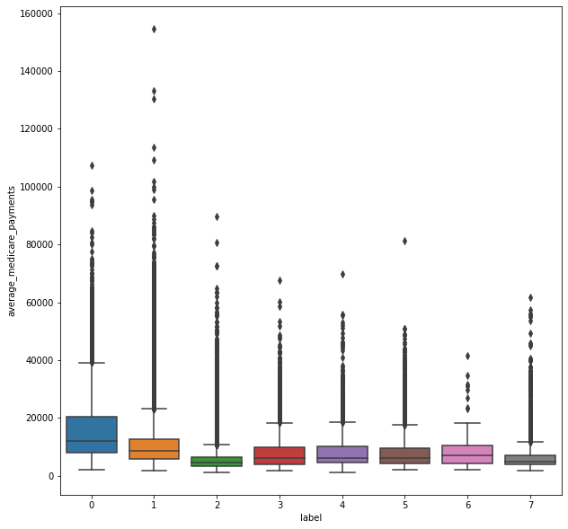

```python
plt.figure(figsize = (10,10))
_ = sns.boxplot(data = data_check, x = 'label', y = 'average_medicare_payments', palette = 'tab10')
```

```python
heat = data_check2.groupby('label').mean()
heat2 = scaler.fit_transform(heat)
heat2 = pd.DataFrame(data = heat2, columns= heat.columns.tolist())
heat2 = pd.concat([pd.DataFrame({ 'label' : heat.index.tolist()}), heat2], axis = 1)
```

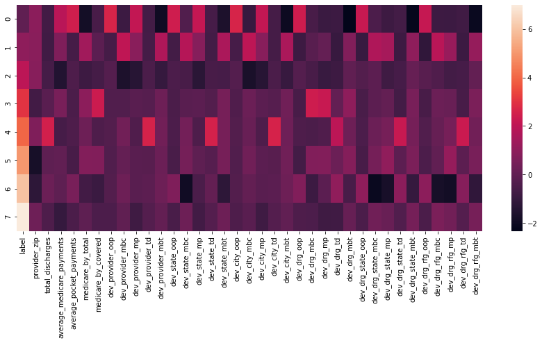

```python
plt.figure(figsize = (15,6))
sns.heatmap(heat2)
_= plt.title("Heatmap of factor values across clusters")
```

A heat-map across all numeric variables also visually differentiates cluster 0. There are far higher bright spots and deep dark spots across multiple features.

### Principal Component Analysis

We use a 2 component PCA to visually estimate how divergent the different clusters are. We performed the following steps:

- Prepared the model and tags *Setup a 2-factor PCA model
- Plotted clusters against the 2 components to visualize divergence.

```python
#Attempting PCA analysis
x = data_model.copy()
y = kmm.labels_
```

```python
from sklearn. decomposition import PCA
pca = PCA(n_components = 2)

principalComponents = pca.fit_transform(x)
principalDf = pd.DataFrame(data = principalComponents
             , columns = ['principal component 1', 'principal component 2'])
finalDf = pd.concat([principalDf, data_check['label']], axis = 1)
```

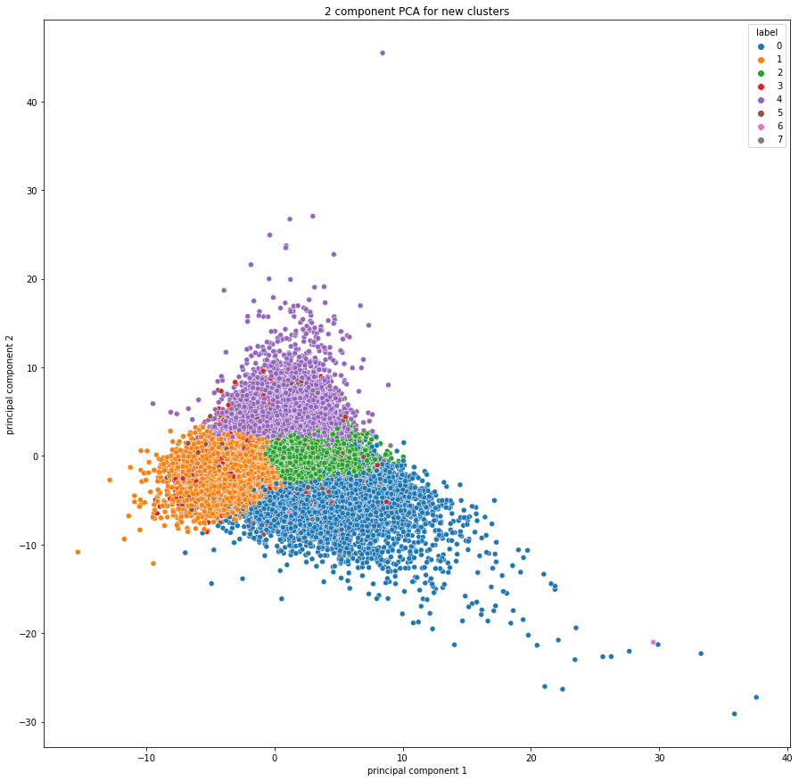

```python
plt.figure(figsize = (15,15))
sns.color_palette('tab10')
sns.scatterplot(x = 'principal component 1', y = 'principal component 2', hue = 'label', data = finalDf, palette='tab10')
plt.title("2 component PCA for new clusters", loc = 'center')
```

Both cluster 0 and cluster 1 can be found on the lower half of the graph, visually seperate from the other clusters. Interestingly, while cluster 0 has far lesser observations than cluster 1, cluster 0 is spread out fruther away from the other clusters. Potentially identifying them as being more accurate outliers.

## Anomaly detetion with PyOD methods

Let us now extend the analysis further using the following PyOD methods:

- KNN
- PCA

### Setting up KNN for outlier identification

We performed the following steps to prepare for KNN based outlier detection:

- Setup a model with default paramaters
- Plotted a histogram using our earlier clusters to explore any overlaps
- Examined features and scores across clusters

```python
#Importing knn packages
from pyod.models.knn import KNN
```

```python
#setting up the model
clf_name = 'knn'
clf = KNN()
clf.fit(data_model)
```

```
KNN(algorithm='auto', contamination=0.1, leaf_size=30, method='largest',
  metric='minkowski', metric_params=None, n_jobs=1, n_neighbors=5, p=2,
  radius=1.0)
```

The KNN Algorithm is similar to the K-means algorithm, in that both focus on calculating euclidean distances and grouping observations which are closer together into the same group. However, While k-means calculates distances from the randomly selected centroids based on the number of required clusters, KNN calculates distances from the center of the entire group of observations. This helps us identify outliers which are far from the center of the group in the n-dimensional space and thereby identify outliers.

```python
data_check['outlier_score'] = clf.decision_scores_
```

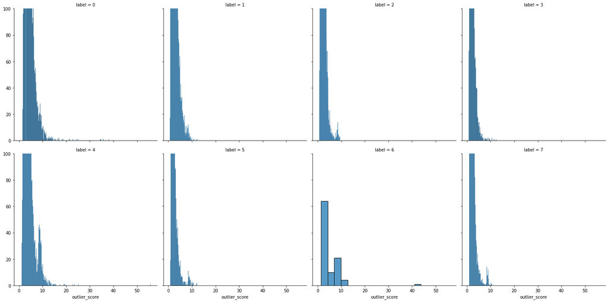

```python
#plt.figure(figsize = (10,10))
g = sns.FacetGrid(data = data_check, col = 'label', col_wrap= 4, height = 5, ylim = (0,100))
g.map(sns.histplot, 'outlier_score', bins = 'auto')
#g.title("Histogram of outlier scores obtained from KNN")
plt.show()
```

The outlier score is a measure of the distance from the center. Which means, the higher the score, the further outside the typical group the observation is. Reinforcing our earlier thought process, Cluster 0 and 4 have far more observations with a higher outlier score.

```python
data_check.groupby('label').median().sort_values(by = 'outlier_score', ascending = False)
```

| label | provider_zip | total_discharges | average_covered_charges | average_total_payments | average_medicare_payments | average_pocket_payments | medicare_by_total | medicare_by_covered | total_by_covered | oop_by_medicare | outlier_score |
| --- | --- | --- | --- | --- | --- | --- | --- | --- | --- | --- | --- |
| 0 | 46107.0 | 24.0 | 51377.25 | 13977.15 | 12147.40 | 1057.30 | 0.901929 | 0.248842 | 0.286928 | 0.108735 | 3.414817 |
| 4 | 44757.5 | 46.0 | 24566.50 | 7340.80 | 6299.60 | 944.20 | 0.863061 | 0.263267 | 0.312629 | 0.158666 | 2.886833 |
| 6 | 39990.0 | 21.5 | 26161.85 | 7802.25 | 7013.15 | 939.15 | 0.852493 | 0.257501 | 0.321074 | 0.173030 | 2.552440 |
| 7 | 51503.0 | 30.0 | 20402.45 | 5951.90 | 4909.55 | 917.50 | 0.840973 | 0.254114 | 0.307918 | 0.189100 | 2.092721 |
| 5 | 46256.0 | 26.0 | 22937.60 | 7075.90 | 6046.40 | 930.90 | 0.861271 | 0.267946 | 0.318003 | 0.161075 | 1.973260 |
| 3 | 40202.0 | 25.0 | 23521.85 | 7093.55 | 6018.95 | 937.55 | 0.854834 | 0.262380 | 0.312234 | 0.169818 | 1.826910 |
| 1 | 44708.0 | 25.0 | 33148.70 | 9612.00 | 8552.00 | 917.40 | 0.894030 | 0.257281 | 0.295950 | 0.118531 | 1.792379 |
| 2 | 43623.0 | 26.0 | 19458.40 | 5621.70 | 4554.00 | 941.10 | 0.822605 | 0.236016 | 0.294317 | 0.215650 | 1.756639 |

As expected, cluster 0 has the highest median outlier score. Interestingly, cluster 4 has the second highest median outlier score. This might mean that there are missed outlier observations which our k-means model did not catch. Or this could also mean that the outliers are atypical observations, maybe popular providers in high-cost regions treating expensive disease groups. Potential for further examination.

```python
data_check['pyOD_KNN_cluster'] = data_check['outlier_score'].apply(lambda x: 1 if x >= 10 else 0)
```

If we classify the observations based on the outlier score (Classified as an outlier if score greater than or equal to 10), we see the following distribution:

```python
data_check['pyOD_KNN_cluster'].value_counts()
```

```
0    162756
1       309
Name: pyOD_KNN_cluster, dtype: int64
```

```python
data_check.groupby('pyOD_KNN_cluster').median().sort_values(by = 'average_medicare_payments', ascending = False)
```

| pyOD_KNN_cluster | provider_zip | total_discharges | average_covered_charges | average_total_payments | average_medicare_payments | average_pocket_payments | medicare_by_total | medicare_by_covered | total_by_covered | oop_by_medicare | label | outlier_score |
| --- | --- | --- | --- | --- | --- | --- | --- | --- | --- | --- | --- | --- |
| 1 | 45429 | 40 | 36274.8 | 12197.4 | 11004.4 | 1046.0 | 0.880607 | 0.274772 | 0.323560 | 0.135580 | 4 | 11.234783 |
| 0 | 44309 | 27 | 25233.3 | 7210.6 | 6155.1 | 935.5 | 0.860148 | 0.248878 | 0.297649 | 0.162591 | 2 | 1.918556 |

However, it is possible we are missing many other outliers.

### KNN with average outlier score of 4 models

```python
#Attempting KNN with mutiple parameters to identify best stable model
from pyod.models.combination import aom, moa, average, maximization
from pyod.utils.utility import standardizer

#Standardize data
#data_model = standardizer(data_model) #Already standardizd using sci-kit learn

#Testing a range of k-neighbours from 10 to 100 in steps of 10.

n_clf = 4
k_list = [10, 50, 100, 150]

#pre-emptive dataframe to store results
train_scores = np.zeros([data_model.shape[0], n_clf])
train_scores.shape

#Modeling
for i in range(n_clf):
  k = k_list[i]
  clf = KNN(n_neighbors=k, method='largest')
  clf.fit(data_model)

  #Store results in each column
  train_scores[:, i] = clf.decision_scores_

#Normalizing scores
train_scores_norm = standardizer(train_scores)
```

```python
#Combination by average
average_scores = average(train_scores_norm)

data_check['average_score'] = average_scores
```

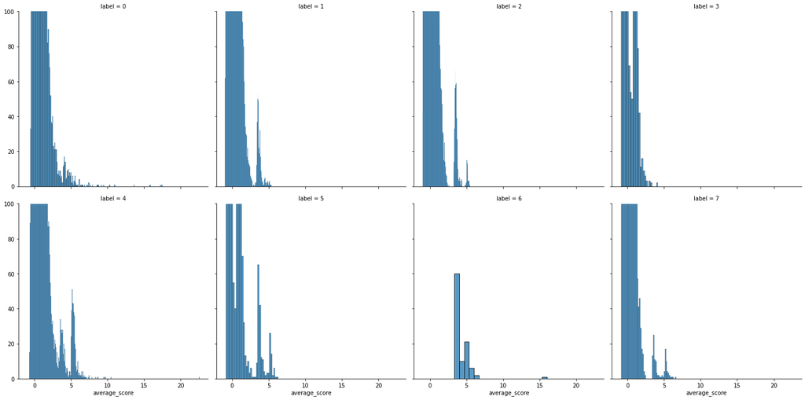

```python
#plt.figure(figsize = (10,10))
g = sns.FacetGrid(data = data_check, col = 'label', col_wrap= 4, height = 5, ylim = (0,100))
g.map(sns.histplot, 'average_score', bins = 'auto')
#g.title("Histogram of outlier scores obtained from KNN")
plt.show()
```

```python
data_check.groupby('label').mean().sort_values(by = 'average_score', ascending = False)
```

| label | provider_zip | total_discharges | average_covered_charges | average_total_payments | average_medicare_payments | average_pocket_payments | medicare_by_total | medicare_by_covered | total_by_covered | oop_by_medicare | outlier_score | pyOD_KNN_cluster | average_score |
| --- | --- | --- | --- | --- | --- | --- | --- | --- | --- | --- | --- | --- | --- |
| 6 | 42954.670000 | 33.030000 | 35447.482000 | 10443.350000 | 9093.681000 | 1349.669000 | 0.840822 | 0.309081 | 0.365239 | 0.207109 | 4.618249 | 0.050000 | 4.306919 |
| 4 | 48381.595541 | 74.044594 | 32094.363244 | 8956.942376 | 7771.247111 | 1185.695266 | 0.851035 | 0.299767 | 0.349821 | 0.186413 | 3.390940 | 0.009896 | 0.779468 |
| 0 | 49180.300079 | 39.975223 | 65681.648741 | 17729.512284 | 15882.032748 | 1847.479536 | 0.877577 | 0.284532 | 0.323221 | 0.157197 | 3.955437 | 0.013241 | 0.693936 |
| 7 | 50605.931561 | 42.824404 | 26637.391524 | 7640.957765 | 6524.802679 | 1116.155086 | 0.832140 | 0.286513 | 0.341617 | 0.216931 | 2.384090 | 0.001256 | 0.343031 |
| 5 | 43874.398263 | 41.146341 | 33245.118410 | 9356.103675 | 8233.518811 | 1122.584865 | 0.849650 | 0.299615 | 0.350677 | 0.190171 | 2.372258 | 0.003675 | 0.340644 |
| 3 | 42835.105716 | 37.538414 | 33287.137185 | 9490.661002 | 8277.701659 | 1212.959342 | 0.843403 | 0.291971 | 0.343833 | 0.201012 | 2.132418 | 0.001229 | 0.036313 |
| 2 | 47268.733630 | 39.398982 | 25206.306017 | 6638.000167 | 5546.013289 | 1091.986878 | 0.813668 | 0.272388 | 0.332373 | 0.246347 | 1.925568 | 0.000000 | -0.152578 |
| 1 | 48617.764295 | 38.834805 | 45769.904107 | 12249.680640 | 10971.241639 | 1278.439000 | 0.876301 | 0.293008 | 0.333239 | 0.152835 | 2.065201 | 0.000316 | -0.180047 |

```python
data_check['KNN_label'] = data_check['average_score'].apply(lambda x: 1 if x >= 5 else 0)
print(data_check['KNN_label'].value_counts())
```

```
0    162413
1       652
Name: KNN_label, dtype: int64
```

With a more stable model, we identified twice the number of outliers which is still a low number considering it is less than 0.5% of the observations. Let us attempt the same using a different algorithm in the next section.

### pyOD using PCA

In the last section, we attempted to build an outlier identifier model using a distance based methods - KNN. In this section, we will attempt to build a model using Principal Components Analysis. PCA is not a distance-based algorithm. Instead it attempts to implode a large number of components into fewer components by combining multiple features into components which are orthogonal to each other. PCA selects for the number of principal components which explain most of the variance.

We will attempt to build multiple models by varying the number of selected components in the model, ranging from 2 to 12.

```python
from pyod.models.pca import PCA

#Setting up the model
n_sel = [2, 4, 6, 8, 10, 12]

#setting up an empty dataframe for labels
train_labels = np.zeros([data_model.shape[0], 6])
train_labels.shape

#importing packages
#from pyod.models.pca import PCA

#Modeling
i = 0
for n in n_sel:
  model = PCA(n_selected_components= n)
  model.fit(data_model)
  #store results in each column
  train_labels[:, i] = model.labels_
  i = i + 1
```

```python
for i in range(6):
  coltitle = "PCA_model" + str(i)
  data_check[coltitle] = train_labels[:, i]
```

Now that we have built the models and stored the labels in our dataframe for checking the results, let us look at the models with 2 components and 12 components below.

```python
data_check.groupby('PCA_model0').mean().sort_values(by = 'average_medicare_payments', ascending = False)
```

| PCA_model0 | provider_zip | total_discharges | average_covered_charges | average_total_payments | average_medicare_payments | average_pocket_payments | medicare_by_total | medicare_by_covered | total_by_covered | oop_by_medicare | label | PCA_model1 | PCA_model2 | PCA_model3 | PCA_model4 | PCA_model5 |
| --- | --- | --- | --- | --- | --- | --- | --- | --- | --- | --- | --- | --- | --- | --- | --- | --- |
| 1.0 | 47939.631815 | 56.380450 | 38922.783394 | 10933.860551 | 9646.182836 | 1287.677715 | 0.846677 | 0.297783 | 0.349354 | 0.196936 | 3.429325 | 0.999632 | 0.999571 | 0.999509 | 0.999509 | 0.999509 |
| 0.0 | 47937.954135 | 41.264681 | 35824.028375 | 9571.160319 | 8366.475513 | 1204.684806 | 0.846529 | 0.283623 | 0.333281 | 0.197033 | 3.454462 | 0.000041 | 0.000048 | 0.000055 | 0.000055 | 0.000055 |

```python
data_check.groupby('PCA_model5').mean().sort_values(by = 'average_medicare_payments', ascending = False)
```

| PCA_model5 | provider_zip | total_discharges | average_covered_charges | average_total_payments | average_medicare_payments | average_pocket_payments | medicare_by_total | medicare_by_covered | total_by_covered | oop_by_medicare | label | PCA_model0 | PCA_model1 | PCA_model2 | PCA_model3 | PCA_model4 |
| --- | --- | --- | --- | --- | --- | --- | --- | --- | --- | --- | --- | --- | --- | --- | --- | --- |
| 1.0 | 47932.781628 | 56.373214 | 38935.475771 | 10939.851082 | 9651.953505 | 1287.897578 | 0.846710 | 0.297816 | 0.349383 | 0.196894 | 3.429999 | 0.999509 | 0.999632 | 0.999755 | 0.999939 | 0.999939 |
| 0.0 | 47938.715293 | 41.265485 | 35822.618063 | 9570.494682 | 8365.834305 | 1204.660376 | 0.846525 | 0.283620 | 0.333278 | 0.197038 | 3.454387 | 0.000055 | 0.000041 | 0.000027 | 0.000007 | 0.000007 |

Interestingly, the model has performed more or less similar with the highest and lowest number of components. This is understandble since most of the variance would have been explained by the first few principal components. Let us look at the percentage of outliers based on the original knn clusters.

```python
data_check[['label', 'average_medicare_payments', 'medicare_by_total', 'PCA_model0', 'PCA_model1', 'PCA_model2', 'PCA_model3', 'PCA_model4', 'PCA_model5']].groupby('label').mean().sort_values(by = 'average_medicare_payments', ascending = False)
```

[output not shown]

```python
data_check[['label', 'KNN_label', 'PCA_model5', 'average_medicare_payments', 'total_discharges', 'medicare_by_total']].groupby(['KNN_label', 'label']).mean()
```

| KNN_label | label | PCA_model5 | average_medicare_payments | total_discharges | medicare_by_total |
| --- | --- | --- | --- | --- | --- |
| 0 | 0 | 0.245445 | 15821.904304 | 39.992210 | 0.877440 |
|  | 1 | 0.065524 | 10970.434833 | 38.832857 | 0.876306 |
|  | 2 | 0.064098 | 5546.850648 | 39.386911 | 0.813687 |
|  | 3 | 0.247695 | 8277.701659 | 37.538414 | 0.843403 |
|  | 4 | 0.220360 | 7792.376113 | 74.333917 | 0.851353 |
|  | 5 | 0.177211 | 8222.225000 | 40.607823 | 0.849787 |
|  | 6 | 1.000000 | 9415.447222 | 30.847222 | 0.844525 |
|  | 7 | 0.124208 | 6531.234326 | 42.782003 | 0.832266 |
| 1 | 0 | 1.000000 | 24315.603704 | 37.592593 | 0.896712 |
|  | 1 | 1.000000 | 13524.985000 | 45.000000 | 0.861337 |
|  | 2 | 1.000000 | 4825.416000 | 49.786667 | 0.797052 |
|  | 4 | 1.000000 | 6877.344974 | 61.804233 | 0.837547 |
|  | 5 | 1.000000 | 8860.005660 | 71.018868 | 0.842056 |
|  | 6 | 1.000000 | 8266.282143 | 38.642857 | 0.831299 |
|  | 7 | 1.000000 | 5832.815909 | 47.386364 | 0.818531 |

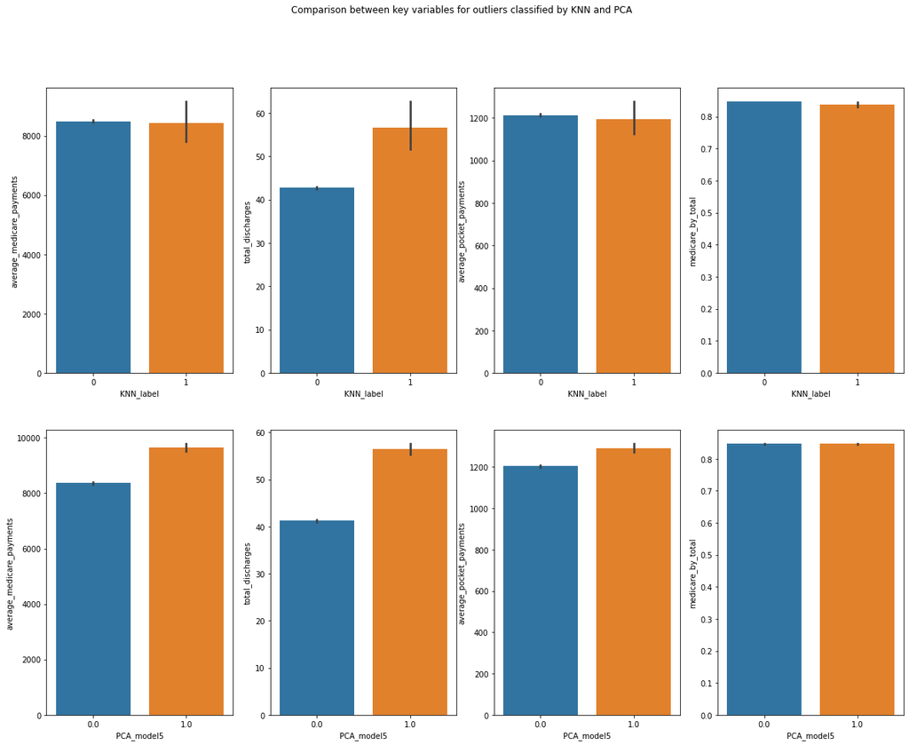

```python
fig, axs = plt.subplots(ncols = 4, nrows = 2, figsize = (20,15))
sns.barplot(x = 'KNN_label', y = 'average_medicare_payments', data = data_check, ax = axs[0, 0])
sns.barplot(x = 'KNN_label', y = 'total_discharges', data = data_check, ax = axs[0, 1])
sns.barplot(x = 'KNN_label', y = 'average_pocket_payments', data = data_check, ax = axs[0, 2])
sns.barplot(x = 'KNN_label', y = 'medicare_by_total', data = data_check, ax = axs[0, 3])
sns.barplot(x = 'PCA_model5', y = 'average_medicare_payments', data = data_check, ax = axs[1, 0])
sns.barplot(x = 'PCA_model5', y = 'total_discharges', data = data_check, ax = axs[1, 1])
sns.barplot(x = 'PCA_model5', y = 'average_pocket_payments', data = data_check, ax = axs[1, 2])
sns.barplot(x = 'PCA_model5', y = 'medicare_by_total', data = data_check, ax = axs[1, 3])
_ = fig.suptitle("Comparison between key variables for outliers classified by KNN and PCA")
```

While PCA seems to have done a better job of identifying outliers with high medicare payments and total discharges, KNN seems to have done a better job in identifying variance between the groups. As a final analysis, let us look where the outliers lie when seen through the PCA chart.

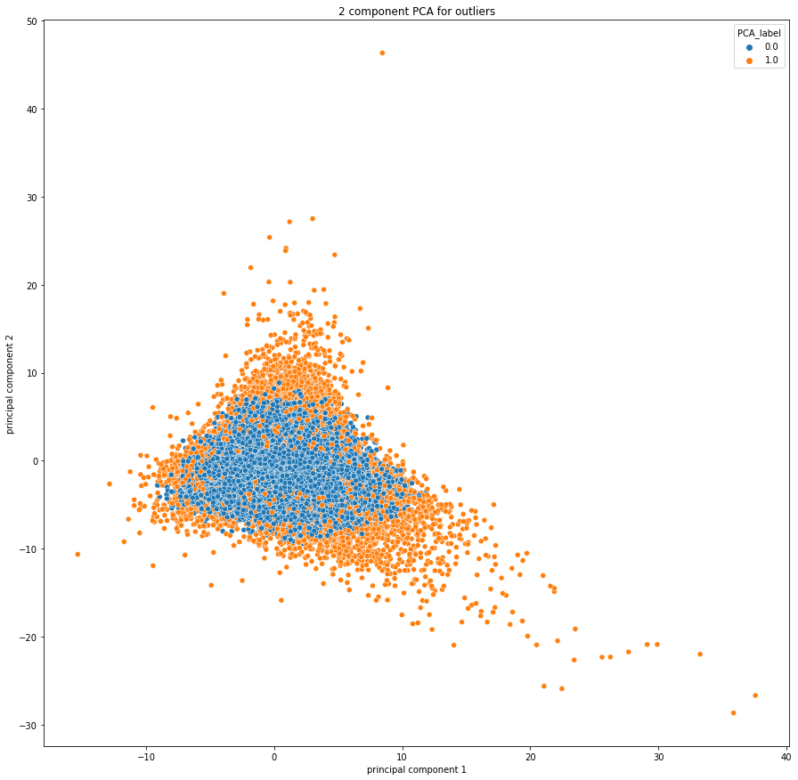

```python
finalDf['PCA_label'] = data_check['PCA_model5']
plt.figure(figsize = (15,15))
sns.color_palette('tab10')
sns.scatterplot(x = 'principal component 1', y = 'principal component 2', hue = 'PCA_label', data = finalDf, palette='tab10')
_ = plt.title("2 component PCA for outliers", loc = 'center')
```

```python
data_check['PCA_model5'].value_counts()
```

```
0.0    146758
1.0     16307
Name: PCA_model5, dtype: int64
```

As can be seen from the plot, PCA model has identified outliers around the cluster that is the center. And with about 10% of the observations identified, this gives us a great simplied list to examine further